# GAM & MARS

Valentina Zangirolami (valentina.zangirolami@unimib.it)

2025-05-07

```r
#load libraries
library(car)
library(ggplot2)
library(ISLR2)
library(splines)
library(earth)
library(tidymodels)
library(mgcv)
library(tidyverse)
```

## *Dataset: College*

```r
data_college = College

head(data_college)
```

```
##                              Private Apps Accept Enroll Top10perc Top25perc
## Abilene Christian University     Yes 1660   1232    721        23        52
## Adelphi University               Yes 2186   1924    512        16        29
## Adrian College                   Yes 1428   1097    336        22        50
## Agnes Scott College              Yes  417    349    137        60        89
## Alaska Pacific University        Yes  193    146     55        16        44
## Albertson College                Yes  587    479    158        38        62
##                              F.Undergrad P.Undergrad Outstate Room.Board Books
## Abilene Christian University        2885         537     7440       3300   450
## Adelphi University                  2683        1227    12280       6450   750
## Adrian College                      1036          99    11250       3750   400
## Agnes Scott College                  510          63    12960       5450   450
## Alaska Pacific University            249         869     7560       4120   800
## Albertson College                    678          41    13500       3335   500
##                              Personal PhD Terminal S.F.Ratio perc.alumni Expend
## Abilene Christian University     2200  70       78      18.1          12   7041
## Adelphi University               1500  29       30      12.2          16  10527
## Adrian College                   1165  53       66      12.9          30   8735
## Agnes Scott College               875  92       97       7.7          37  19016
## Alaska Pacific University        1500  76       72      11.9           2  10922
## Albertson College                 675  67       73       9.4          11   9727
##                              Grad.Rate
## Abilene Christian University        60
## Adelphi University                  56
## Adrian College                      54
## Agnes Scott College                 59
## Alaska Pacific University           15
## Albertson College                   55
```

College dataset is contained in ISLR2 library. You can find the description of the variables in R while searching “College” in **Help**. **Our goal**: predict the number of enrollments for each new college.

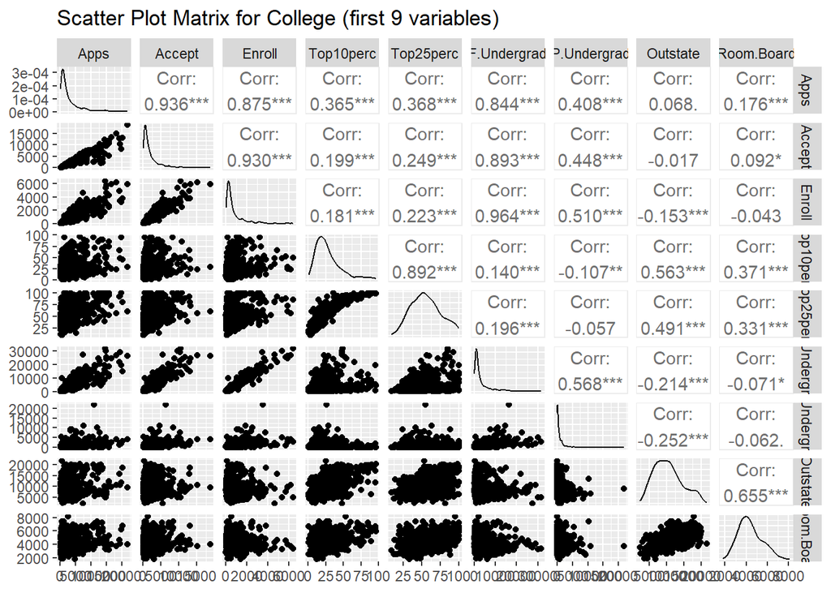

```r
#marginal interpretation

(Scatter_Matrix <- GGally::ggpairs(data_college[,c(2:10)],
                                   title = "Scatter Plot Matrix for College (first 9 variables)",
                                   axisLabels = "show"))
```

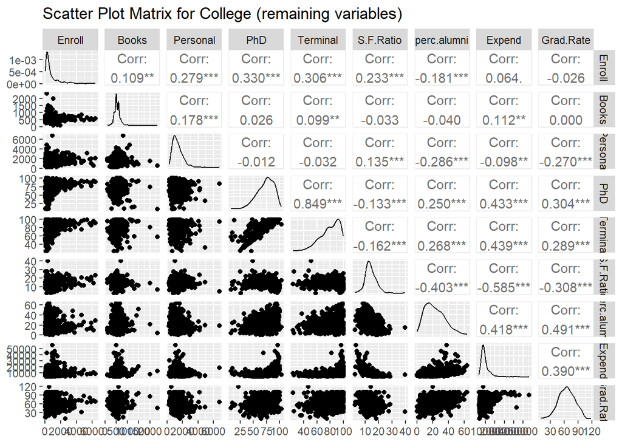

```r
(Scatter_Matrix_2 <- GGally::ggpairs(data_college[,c(4, 11:18)],
                                   title = "Scatter Plot Matrix for College (remaining variables)",
                                   axisLabels = "show"))
```

Marginally, the relationships between Enroll and some covariates (such as Accept, Apps, F.Undergrad) seem to be linear. For other covariates (such as PhD, terminal, perc. Alumni), we can observe a clear non-linear pattern with Enroll. However, the marginal interpretation is not always clear, but, in general, we need to overcome linear relationships between response (Enroll) and covariates.

### **Generalized Additive Models (GAMs)**

GAM allows us to model non-linear relationships when many covariates are involved.

Before starting, we can split our dataset in the training and validation sets as follows

```r
set.seed(123)  # For reproducibility
split <- initial_split(data_college, prop = 0.8)

train_data <- training(split)
val_data <- testing(split)
```

(Instead of holdout sample, you can use also cross-validation. In the following classes, we shall consider it.)

Since we are considering *Enroll* as response variable, we need to model the response in an appropriate way.

If we would like to include natural splines for many covariates, it is not necessary leveraging backfitting algorithm. Indeed, we can include each natural spline in the classical formula of Generalized Linear model.

Generally, we assume $Enroll \sim Pois(\mu)$ where

$$log(\mu) = \beta_0 + \sum_{i=1}^{17}
f_i(X^{i})$$
with $X^{(i)}$ meaning the 17 covariates.

```r
gam_1 <- glm(Enroll ~ Apps + Accept + Private + F.Undergrad + ns(Top10perc, 3) + ns(Top25perc,3) + P.Undergrad + ns(Outstate,3) + ns(Room.Board, 4) + ns(Books) + ns(Personal,3) + ns(PhD,3) + ns(Terminal,3) + ns(S.F.Ratio,3) + ns(perc.alumni,3) + ns(Expend,3) + ns(Grad.Rate,3),family=poisson, data=train_data)

summary(gam_1)
```

```
##
## Call:
## glm(formula = Enroll ~ Apps + Accept + Private + F.Undergrad +
##     ns(Top10perc, 3) + ns(Top25perc, 3) + P.Undergrad + ns(Outstate,
##     3) + ns(Room.Board, 4) + ns(Books) + ns(Personal, 3) + ns(PhD,
##     3) + ns(Terminal, 3) + ns(S.F.Ratio, 3) + ns(perc.alumni,
##     3) + ns(Expend, 3) + ns(Grad.Rate, 3), family = poisson,
##     data = train_data)
##
## Coefficients:
##                       Estimate Std. Error z value Pr(>|z|)
## (Intercept)          6.015e+00  3.921e-02 153.380  < 2e-16 ***
## Apps                 3.617e-05  1.357e-06  26.648  < 2e-16 ***
## Accept               9.373e-05  2.084e-06  44.976  < 2e-16 ***
## PrivateYes          -3.284e-01  6.088e-03 -53.941  < 2e-16 ***
## F.Undergrad          3.418e-05  7.164e-07  47.716  < 2e-16 ***
## ns(Top10perc, 3)1    2.808e-01  1.647e-02  17.049  < 2e-16 ***
## ns(Top10perc, 3)2    5.709e-01  3.276e-02  17.427  < 2e-16 ***
## ns(Top10perc, 3)3    4.655e-01  2.361e-02  19.713  < 2e-16 ***
## ns(Top25perc, 3)1    2.905e-02  1.453e-02   1.999 0.045563 *
## ns(Top25perc, 3)2   -4.206e-01  4.077e-02 -10.316  < 2e-16 ***
## ns(Top25perc, 3)3   -4.652e-01  1.889e-02 -24.633  < 2e-16 ***
## P.Undergrad          1.536e-05  8.328e-07  18.444  < 2e-16 ***
## ns(Outstate, 3)1    -2.186e-01  1.179e-02 -18.552  < 2e-16 ***
## ns(Outstate, 3)2    -7.079e-01  2.376e-02 -29.799  < 2e-16 ***
## ns(Outstate, 3)3     5.721e-02  1.712e-02   3.342 0.000831 ***
## ns(Room.Board, 4)1  -3.818e-01  1.371e-02 -27.851  < 2e-16 ***
## ns(Room.Board, 4)2  -3.292e-01  1.256e-02 -26.221  < 2e-16 ***
## ns(Room.Board, 4)3  -3.653e-01  3.116e-02 -11.725  < 2e-16 ***
## ns(Room.Board, 4)4   2.177e-01  1.866e-02  11.666  < 2e-16 ***
## ns(Books)            4.205e-01  3.023e-02  13.908  < 2e-16 ***
## ns(Personal, 3)1     2.058e-01  1.082e-02  19.011  < 2e-16 ***
## ns(Personal, 3)2     7.684e-01  2.490e-02  30.865  < 2e-16 ***
## ns(Personal, 3)3     5.237e-01  3.084e-02  16.985  < 2e-16 ***
## ns(PhD, 3)1          2.514e-01  1.981e-02  12.688  < 2e-16 ***
## ns(PhD, 3)2          3.450e-01  6.010e-02   5.740 9.45e-09 ***
## ns(PhD, 3)3          1.024e-01  1.797e-02   5.700 1.20e-08 ***
## ns(Terminal, 3)1     4.083e-01  2.005e-02  20.361  < 2e-16 ***
## ns(Terminal, 3)2     9.594e-02  5.601e-02   1.713 0.086723 .
## ns(Terminal, 3)3     5.644e-02  1.487e-02   3.797 0.000147 ***
## ns(S.F.Ratio, 3)1    4.066e-01  1.559e-02  26.076  < 2e-16 ***
## ns(S.F.Ratio, 3)2   -2.191e-01  3.944e-02  -5.556 2.76e-08 ***
## ns(S.F.Ratio, 3)3   -4.483e-01  4.538e-02  -9.878  < 2e-16 ***
## ns(perc.alumni, 3)1 -1.194e-01  8.458e-03 -14.117  < 2e-16 ***
## ns(perc.alumni, 3)2  1.052e-01  2.126e-02   4.946 7.57e-07 ***
## ns(perc.alumni, 3)3 -4.415e-02  1.646e-02  -2.683 0.007292 **
## ns(Expend, 3)1       3.066e-01  2.007e-02  15.275  < 2e-16 ***
## ns(Expend, 3)2       1.731e-01  2.630e-02   6.583 4.60e-11 ***
## ns(Expend, 3)3       3.906e-01  2.430e-02  16.076  < 2e-16 ***
## ns(Grad.Rate, 3)1   -1.180e-01  1.120e-02 -10.529  < 2e-16 ***
## ns(Grad.Rate, 3)2    2.918e-01  3.406e-02   8.565  < 2e-16 ***
## ns(Grad.Rate, 3)3    7.978e-01  1.928e-02  41.379  < 2e-16 ***
## ---
## Signif. codes:  0 '***' 0.001 '**' 0.01 '*' 0.05 '.' 0.1 ' ' 1
##
## (Dispersion parameter for poisson family taken to be 1)
##
##     Null deviance: 425390  on 619  degrees of freedom
## Residual deviance:  51204  on 579  degrees of freedom
## AIC: 56241
##
## Number of Fisher Scoring iterations: 4
```

Specifically, the estimated model corresponds to

$$log(\mu_i) = 6.01 + 0.00004 Apps_i +
0.00009 Accept_i -0.33 D_i + 0.00003 F.Undergrad + 0.28 b_1(Top10perc) +
0.57b_2(Top10perc) + 0.47 b_3(Top10perc) + 0.03 b_4(Top25perc)
-0.42b_5(Top25perc) - 0.47 b_6(Top25perc) + \ldots,$$

where $b_1, b_2, b_3, b_4, b_5, b_6$ are basis functions.

**Comments**

- Most of coefficients are significant at any $\alpha$ level (except to ns(Top25perc, 3)1, ns(Terminal, 3)2, ns(perc.alumni, 3)3 )
- The test about overall significance:

```r
mod_0 <- glm(Enroll ~ 1, family=poisson, data=train_data)
anova(mod_0,gam_1,test="Chisq")
```

```
## Analysis of Deviance Table
##
## Model 1: Enroll ~ 1
## Model 2: Enroll ~ Apps + Accept + Private + F.Undergrad + ns(Top10perc,
##     3) + ns(Top25perc, 3) + P.Undergrad + ns(Outstate, 3) + ns(Room.Board,
##     4) + ns(Books) + ns(Personal, 3) + ns(PhD, 3) + ns(Terminal,
##     3) + ns(S.F.Ratio, 3) + ns(perc.alumni, 3) + ns(Expend, 3) +
##     ns(Grad.Rate, 3)
##   Resid. Df Resid. Dev Df Deviance  Pr(>Chi)
## 1       619     425390
## 2       579      51204 40   374186 < 2.2e-16 ***
## ---
## Signif. codes:  0 '***' 0.001 '**' 0.01 '*' 0.05 '.' 0.1 ' ' 1
```

The hypothesis of non-significance of all coefficients is rejected.

When we want to include splies as smoothing splines, we need to use backfitting algorithm by using the function *gam*, as follows

```r
gam_2 <- gam(Enroll ~ Apps + Accept + Private + F.Undergrad +
             s(Top10perc, k=3) + s(Top25perc, k=3) + P.Undergrad +
             s(Outstate, k=3) + s(Room.Board, k=4) + s(Books, k=3) +
             s(Personal, k=3) + s(PhD, k=3) + s(Terminal, k=3) +
             s(S.F.Ratio, k=3) + s(perc.alumni, k=3) + s(Expend, k=3) +
             s(Grad.Rate, k=3),
             family = poisson(),
             data = train_data,
             method = "REML")

summary(gam_2)
```

```
##
## Family: poisson
## Link function: log
##
## Formula:
## Enroll ~ Apps + Accept + Private + F.Undergrad + s(Top10perc,
##     k = 3) + s(Top25perc, k = 3) + P.Undergrad + s(Outstate,
##     k = 3) + s(Room.Board, k = 4) + s(Books, k = 3) + s(Personal,
##     k = 3) + s(PhD, k = 3) + s(Terminal, k = 3) + s(S.F.Ratio,
##     k = 3) + s(perc.alumni, k = 3) + s(Expend, k = 3) + s(Grad.Rate,
##     k = 3)
##
## Parametric coefficients:
##               Estimate Std. Error z value Pr(>|z|)
## (Intercept)  6.158e+00  5.412e-03 1137.98   <2e-16 ***
## Apps         4.002e-05  1.322e-06   30.28   <2e-16 ***
## Accept       9.193e-05  2.030e-06   45.28   <2e-16 ***
## PrivateYes  -3.756e-01  5.978e-03  -62.83   <2e-16 ***
## F.Undergrad  3.032e-05  6.706e-07   45.22   <2e-16 ***
## P.Undergrad  1.334e-05  7.813e-07   17.07   <2e-16 ***
## ---
## Signif. codes:  0 '***' 0.001 '**' 0.01 '*' 0.05 '.' 0.1 ' ' 1
##
## Approximate significance of smooth terms:
##                  edf Ref.df Chi.sq p-value
## s(Top10perc)   1.995  2.000  618.7  <2e-16 ***
## s(Top25perc)   1.999  2.000 1415.9  <2e-16 ***
## s(Outstate)    1.999  2.000 1688.7  <2e-16 ***
## s(Room.Board)  2.996  3.000 2939.8  <2e-16 ***
## s(Books)       1.922  1.994  372.5  <2e-16 ***
## s(Personal)    1.945  1.997 1617.4  <2e-16 ***
## s(PhD)         1.991  2.000  164.9  <2e-16 ***
## s(Terminal)    1.997  2.000  609.1  <2e-16 ***
## s(S.F.Ratio)   1.976  1.999 1020.9  <2e-16 ***
## s(perc.alumni) 1.039  1.077  203.0  <2e-16 ***
## s(Expend)      1.952  1.998  658.2  <2e-16 ***
## s(Grad.Rate)   1.999  2.000 2505.6  <2e-16 ***
## ---
## Signif. codes:  0 '***' 0.001 '**' 0.01 '*' 0.05 '.' 0.1 ' ' 1
##
## R-sq.(adj) =  0.843   Deviance explained =   87%
## -REML =  30364  Scale est. = 1         n = 620
```

All the coefficients are significant and the R2 adj is really high. This means that the model is good and it is likely to fit well data.

**Comparison of predictions**

```r
pred_gam_1_train <- predict(gam_1, train_data[,-4], type = "response")
pred_gam_2_train <- predict(gam_2, train_data[,-4], type = "response")

pred_gam_1 <- predict(gam_1, val_data[,-4], type = "response")
pred_gam_2 <- predict(gam_2, val_data[,-4], type = "response")

rmse <- function(actual, predicted) {
  sqrt(mean((actual - predicted)^2))
}
cat("RMSE on training data \n")
```

```
## RMSE on training data
```

```r
(rmse_gam_1_train <- rmse(train_data$Enroll, pred_gam_1_train))
```

```
## [1] 308.7867
```

```r
(rmse_gam_2_train <- rmse(train_data$Enroll, pred_gam_2_train))
```

```
## [1] 332.1803
```

```r
cat("RMSE on validation data \n")
```

```
## RMSE on validation data
```

```r
(rmse_gam_1 <- rmse(val_data$Enroll, pred_gam_1))
```

```
## [1] 1076.635
```

```r
(rmse_gam_2 <- rmse(val_data$Enroll, pred_gam_2))
```

```
## [1] 932.6131
```

The RMSE is better in the first model while considering training set. But in the first model we can see a big issue about overfitting. The second model performs better in the validation set even if it also suffers from overfitting.

**Multivariate Adaptive Regression Splines**

```r
mars1 <- earth(Enroll ~ .,  data = train_data, glm=list(family=poisson))
mars1$cuts
```

```
##                      PrivateYes Apps Accept Top10perc Top25perc F.Undergrad
## (Intercept)                   0    0      0         0         0           0
## h(F.Undergrad-16505)          0    0      0         0         0       16505
## h(16505-F.Undergrad)          0    0      0         0         0       16505
## h(Accept-5125)                0    0   5125         0         0           0
## h(5125-Accept)                0    0   5125         0         0           0
## h(Accept-8683)                0    0   8683         0         0           0
## h(Room.Board-5072)            0    0      0         0         0           0
## h(5072-Room.Board)            0    0      0         0         0           0
## h(Top10perc-57)               0    0      0        57         0           0
## h(57-Top10perc)               0    0      0        57         0           0
## h(Apps-7294)                  0 7294      0         0         0           0
## h(7294-Apps)                  0 7294      0         0         0           0
##                      P.Undergrad Outstate Room.Board Books Personal PhD
## (Intercept)                    0        0          0     0        0   0
## h(F.Undergrad-16505)           0        0          0     0        0   0
## h(16505-F.Undergrad)           0        0          0     0        0   0
## h(Accept-5125)                 0        0          0     0        0   0
## h(5125-Accept)                 0        0          0     0        0   0
## h(Accept-8683)                 0        0          0     0        0   0
## h(Room.Board-5072)             0        0       5072     0        0   0
## h(5072-Room.Board)             0        0       5072     0        0   0
## h(Top10perc-57)                0        0          0     0        0   0
## h(57-Top10perc)                0        0          0     0        0   0
## h(Apps-7294)                   0        0          0     0        0   0
## h(7294-Apps)                   0        0          0     0        0   0
##                      Terminal S.F.Ratio perc.alumni Expend Grad.Rate
## (Intercept)                 0         0           0      0         0
## h(F.Undergrad-16505)        0         0           0      0         0
## h(16505-F.Undergrad)        0         0           0      0         0
## h(Accept-5125)              0         0           0      0         0
## h(5125-Accept)              0         0           0      0         0
## h(Accept-8683)              0         0           0      0         0
## h(Room.Board-5072)          0         0           0      0         0
## h(5072-Room.Board)          0         0           0      0         0
## h(Top10perc-57)             0         0           0      0         0
## h(57-Top10perc)             0         0           0      0         0
## h(Apps-7294)                0         0           0      0         0
## h(7294-Apps)                0         0           0      0         0
```

```r
mars1$coefficients
```

```
##                             Enroll
## (Intercept)          2749.44307884
## h(F.Undergrad-16505)    0.17687808
## h(16505-F.Undergrad)   -0.11434320
## h(5125-Accept)         -0.24089129
## h(Accept-8683)          0.27236189
## h(5072-Room.Board)      0.05680898
## h(Top10perc-57)        10.01226571
## h(7294-Apps)            0.04504267
```

From the output *cuts* we can observe all the basis function considered by MARS model and related cuts.

The estimated equation corresponds to

$$\log(\widehat{\text{Enroll}}) = \
2749.4431 + 0.1769 \cdot h(\text{F.Undergrad} - 16505) - 0.1143 \cdot
h(16505 - \text{F.Undergrad}) - 0.2409 \cdot h(5125 - \text{Accept}) +
0.2724 \cdot h(\text{Accept} - 8683) + 0.0568 \cdot h(5072 -
\text{Room.Board}) + 10.0123 \cdot h(\text{Top10perc} - 57) + 0.0450
\cdot h(7294 - \text{Apps})$$

where $h(x) = max(0,x)$.

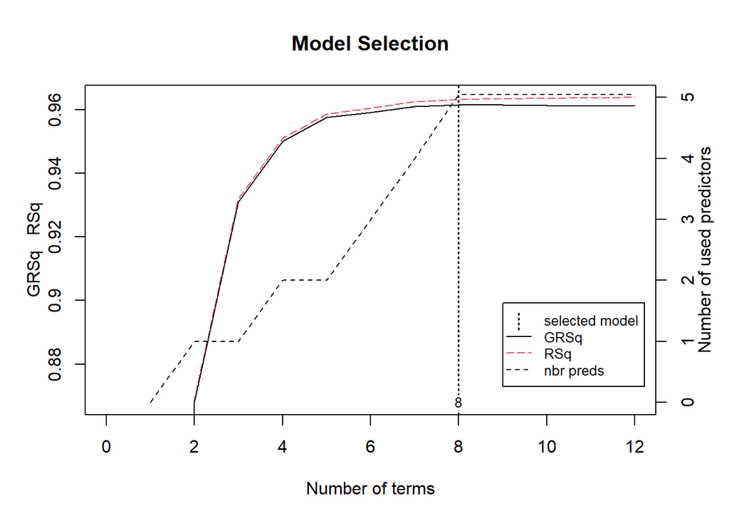

```r
plot(mars1, which=1)
```

Comments:

- GRSq stands for Generalized R-Squared: it is penalized by the complexity of the model.
- RSq stands for R-squared
- nbr preds stands for number of unique predictors

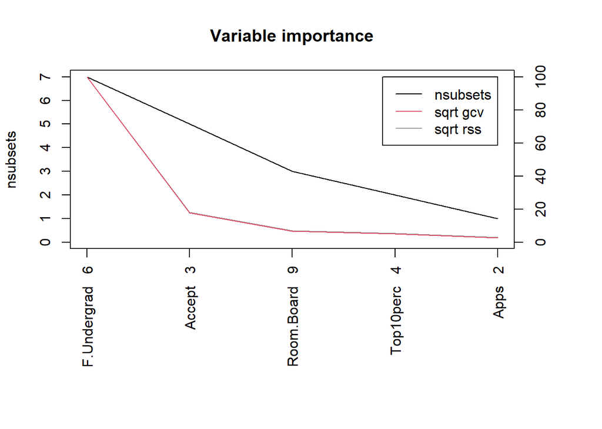

```r
plot(evimp(mars1))
```

The plot shows how many subsets contain the variables in the x-axis and how much the residual sum of squares and the generalized cross-validation decrease when each variable is included in the model. *F. Undergrad* is the covariate most included in the subsets while after including *Accept* we have the most strong decrease of RSS and GCV.

```r
#train
pred_mars_1_train <- predict(mars1, train_data[,-4], type = "response")
#val
pred_mars_1 <- predict(mars1, val_data[,-4], type = "response")

cat("RMSE on training data \n")
```

```
## RMSE on training data
```

```r
(rmse_mars_1_train <- rmse(train_data$Enroll, pred_mars_1_train)) #225.46
```

```
## [1] 225.4608
```

```r
cat("RMSE on validation data \n")
```

```
## RMSE on validation data
```

```r
(rmse_mars_1<- rmse(val_data$Enroll, pred_mars_1)) #321.21
```

```
## [1] 321.2137
```

MARS model is better than GAMs and it overcomes overfitting concerns.

## **Classification task**

Let’s consider the same dataset by trasforming our response variable (*Enroll*) in a binary one. We can define the new variable as

```r
data_college <- data_college |>
  mutate(Y = if_else(Enroll > 430, 1, 0))

data_college <- data_college |> select(-Enroll)
```

In Binary tasks, it’s always important to check if the response variable is balanced or not.

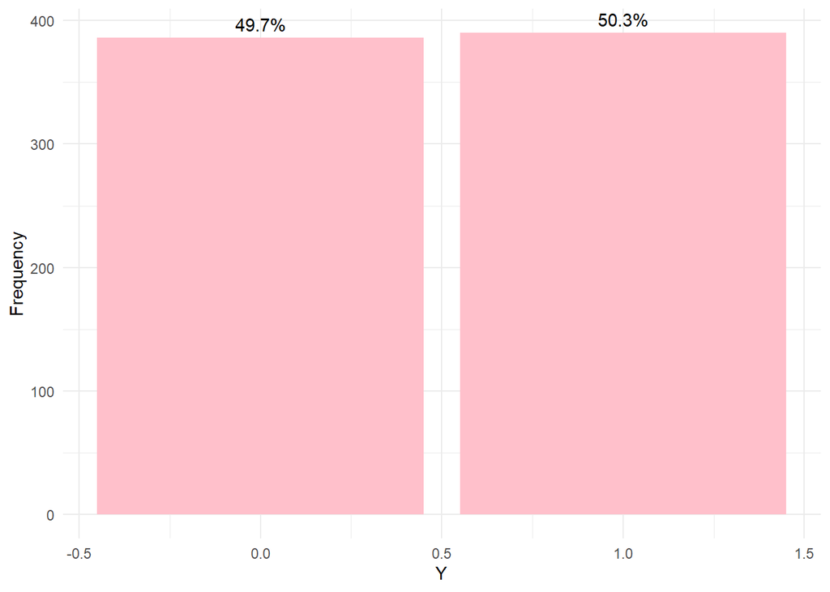

```r
ggplot(data_college, aes(x = Y)) +
  geom_bar(aes(y = ..count..), fill = "pink") +
  geom_text(aes(label = scales::percent(..prop.., accuracy = 0.1),
                y = ..count..),
            stat = "count",
            vjust = -0.5) +
  labs(x = "Y",
       y = "Frequency") +
  theme_minimal()
```

The two categories are balanced. Then, we don’t need to use specific method to deal with imbalanced response issues. Now, let’s split again in training and validation sets

```r
# Set seed for reproducibility
set.seed(123)

# Create stratified split
split_obj <- initial_split(data_college, prop = 0.8, strata = Y)  # Stratify by the binary variable

# Extract the splits
train_data <- training(split_obj)
val_data <- testing(split_obj)
```

### **Generalized Additive Models (GAMs)**

We can try to fit the same models by changing distribution family as follows

```r
#Gam with natural splines

gam_1 <- glm(Y ~ Apps + Accept + Private + F.Undergrad + ns(Top10perc, 3) + ns(Top25perc,3) + P.Undergrad + ns(Outstate,3) + ns(Room.Board, 4) + ns(Books) + ns(Personal,3) + ns(PhD,3) + ns(Terminal,3) + ns(S.F.Ratio,3) + ns(perc.alumni,3) + ns(Expend,3) + ns(Grad.Rate,3),family=binomial, data=train_data)
summary(gam_1)
```

```
##
## Call:
## glm(formula = Y ~ Apps + Accept + Private + F.Undergrad + ns(Top10perc,
##     3) + ns(Top25perc, 3) + P.Undergrad + ns(Outstate, 3) + ns(Room.Board,
##     4) + ns(Books) + ns(Personal, 3) + ns(PhD, 3) + ns(Terminal,
##     3) + ns(S.F.Ratio, 3) + ns(perc.alumni, 3) + ns(Expend, 3) +
##     ns(Grad.Rate, 3), family = binomial, data = train_data)
##
## Coefficients:
##                       Estimate Std. Error z value Pr(>|z|)
## (Intercept)         -16.409677  14.066211  -1.167  0.24337
## Apps                 -0.001320   0.001329  -0.993  0.32060
## Accept                0.008656   0.002651   3.265  0.00110 **
## PrivateYes            4.786249   2.068335   2.314  0.02066 *
## F.Undergrad           0.010357   0.002317   4.471  7.8e-06 ***
## ns(Top10perc, 3)1     2.718003   4.902866   0.554  0.57933
## ns(Top10perc, 3)2    11.505523  11.905980   0.966  0.33386
## ns(Top10perc, 3)3     3.877826   7.815544   0.496  0.61978
## ns(Top25perc, 3)1    -2.864007   4.466914  -0.641  0.52142
## ns(Top25perc, 3)2     2.706646  14.549534   0.186  0.85242
## ns(Top25perc, 3)3     7.473382   5.520451   1.354  0.17581
## P.Undergrad          -0.001958   0.001015  -1.929  0.05379 .
## ns(Outstate, 3)1     -2.648140   3.535007  -0.749  0.45379
## ns(Outstate, 3)2    -23.455923   8.791335  -2.668  0.00763 **
## ns(Outstate, 3)3     -4.981778   4.604694  -1.082  0.27930
## ns(Room.Board, 4)1  -10.668337   5.168804  -2.064  0.03902 *
## ns(Room.Board, 4)2  -11.119152   5.038208  -2.207  0.02732 *
## ns(Room.Board, 4)3  -13.586862  10.153214  -1.338  0.18084
## ns(Room.Board, 4)4    2.976876   4.612262   0.645  0.51865
## ns(Books)           -13.082215   8.954319  -1.461  0.14402
## ns(Personal, 3)1      1.655487   5.380754   0.308  0.75833
## ns(Personal, 3)2      0.563674  20.861946   0.027  0.97844
## ns(Personal, 3)3      5.893896  39.791924   0.148  0.88225
## ns(PhD, 3)1          -1.746313   3.150441  -0.554  0.57937
## ns(PhD, 3)2          -9.415054   9.359692  -1.006  0.31446
## ns(PhD, 3)3          -3.198799   2.807705  -1.139  0.25458
## ns(Terminal, 3)1      3.676271   4.525702   0.812  0.41661
## ns(Terminal, 3)2      8.842038  11.955831   0.740  0.45957
## ns(Terminal, 3)3      1.403651   2.909394   0.482  0.62948
## ns(S.F.Ratio, 3)1    -1.716127   5.345249  -0.321  0.74817
## ns(S.F.Ratio, 3)2    -7.531943  37.133251  -0.203  0.83926
## ns(S.F.Ratio, 3)3   -16.190455  47.457969  -0.341  0.73299
## ns(perc.alumni, 3)1   9.015937   3.056756   2.950  0.00318 **
## ns(perc.alumni, 3)2  19.018525   7.853030   2.422  0.01544 *
## ns(perc.alumni, 3)3   3.705069   4.439455   0.835  0.40396
## ns(Expend, 3)1      -19.759772   9.484096  -2.083  0.03721 *
## ns(Expend, 3)2       28.714670  19.685943   1.459  0.14466
## ns(Expend, 3)3       86.414820  41.954068   2.060  0.03942 *
## ns(Grad.Rate, 3)1    -0.747635   2.847854  -0.263  0.79292
## ns(Grad.Rate, 3)2     3.642951   8.188382   0.445  0.65640
## ns(Grad.Rate, 3)3    -0.958388   2.929301  -0.327  0.74354
## ---
## Signif. codes:  0 '***' 0.001 '**' 0.01 '*' 0.05 '.' 0.1 ' ' 1
##
## (Dispersion parameter for binomial family taken to be 1)
##
##     Null deviance: 859.477  on 619  degrees of freedom
## Residual deviance:  78.471  on 579  degrees of freedom
## AIC: 160.47
##
## Number of Fisher Scoring iterations: 13
```

```r
#GAM with smoothing splines

gam_2 <- gam(Y ~ Apps + Accept + Private + F.Undergrad +
               s(Top10perc, k=3) + s(Top25perc, k=3) + P.Undergrad +
               s(Outstate, k=3) + s(Room.Board, k=4) + s(Books, k=3) +
               s(Personal, k=3) + s(PhD, k=3) + s(Terminal, k=3) +
               s(S.F.Ratio, k=3) + s(perc.alumni, k=3) + s(Expend, k=3) +
               s(Grad.Rate, k=3),
             family = binomial(),
             data = train_data,
             method = "REML")

summary(gam_2)
```

```
##
## Family: binomial
## Link function: logit
##
## Formula:
## Y ~ Apps + Accept + Private + F.Undergrad + s(Top10perc, k = 3) +
##     s(Top25perc, k = 3) + P.Undergrad + s(Outstate, k = 3) +
##     s(Room.Board, k = 4) + s(Books, k = 3) + s(Personal, k = 3) +
##     s(PhD, k = 3) + s(Terminal, k = 3) + s(S.F.Ratio, k = 3) +
##     s(perc.alumni, k = 3) + s(Expend, k = 3) + s(Grad.Rate, k = 3)
##
## Parametric coefficients:
##               Estimate Std. Error z value Pr(>|z|)
## (Intercept) -1.883e+01  2.986e+00  -6.307 2.84e-10 ***
## Apps        -9.488e-04  8.184e-04  -1.159   0.2463
## Accept       6.840e-03  1.610e-03   4.247 2.16e-05 ***
## PrivateYes   2.247e+00  1.246e+00   1.804   0.0712 .
## F.Undergrad  6.505e-03  1.196e-03   5.441 5.31e-08 ***
## P.Undergrad -1.420e-03  7.271e-04  -1.952   0.0509 .
## ---
## Signif. codes:  0 '***' 0.001 '**' 0.01 '*' 0.05 '.' 0.1 ' ' 1
##
## Approximate significance of smooth terms:
##                  edf Ref.df Chi.sq p-value
## s(Top10perc)   1.000  1.000  2.151 0.14244
## s(Top25perc)   1.000  1.000  0.032 0.85739
## s(Outstate)    1.000  1.000  2.193 0.13861
## s(Room.Board)  2.654  2.925 14.683 0.00333 **
## s(Books)       1.000  1.000  3.815 0.05080 .
## s(Personal)    1.000  1.000  0.299 0.58470
## s(PhD)         1.000  1.000  2.950 0.08588 .
## s(Terminal)    1.000  1.000  1.384 0.23949
## s(S.F.Ratio)   1.000  1.000  0.709 0.39987
## s(perc.alumni) 1.646  1.868  7.039 0.06174 .
## s(Expend)      1.730  1.922  3.147 0.25696
## s(Grad.Rate)   1.000  1.000  0.369 0.54352
## ---
## Signif. codes:  0 '***' 0.001 '**' 0.01 '*' 0.05 '.' 0.1 ' ' 1
##
## R-sq.(adj) =    0.9   Deviance explained = 88.6%
## -REML = 77.178  Scale est. = 1         n = 620
```

In this case, we can evaluate our predictions using the accuracy (percentage of observations classified correctly), as follows

```r
#prediction
#train
pred_gam_1_train <- predict(gam_1, train_data[,-18], type = "response")
pred_gam_2_train <- predict(gam_2, train_data[,-18], type = "response")

#val
pred_gam_1 <- predict(gam_1, val_data[,-18], type = "response")
pred_gam_2 <- predict(gam_2, val_data[,-18], type = "response")


accuracy <- function(truth, predicted) {
  mean(truth == predicted)
}

pred_gam_1_train <- ifelse(pred_gam_1_train >0.5, 1, 0 )
pred_gam_2_train <- ifelse(pred_gam_2_train >0.5, 1, 0 )

cat("Accuracy on training data \n")
```

```
## Accuracy on training data
```

```r
(acc_gam_1_train <- accuracy(train_data$Y, pred_gam_1_train)) #0.973
```

```
## [1] 0.9725806
```

```r
(acc_gam_2_train <- accuracy(train_data$Y, pred_gam_2_train)) #0.971
```

```
## [1] 0.9709677
```

The values of accuracy are closed to 1… this means that the models are quite good!

```r
pred_gam_1 <- ifelse(pred_gam_1 >0.5, 1, 0 )
pred_gam_2 <- ifelse(pred_gam_2 >0.5, 1, 0 )

cat("Accuracy on validation data \n")
```

```
## Accuracy on validation data
```

```r
(acc_gam_1 <- accuracy(val_data$Y, pred_gam_1)) #0.942
```

```
## [1] 0.9423077
```

```r
(acc_gam_2 <- accuracy(val_data$Y, pred_gam_2)) #0.949
```

```
## [1] 0.9487179
```

Also in the validation set, the values of accuracy are quite good! Even in this case, we can see that in the training set we obtained higher values. However, we don’t have strong concerns.

### **Multivariate Adaptive Regression Splines**

```r
mars1 <- earth(Y ~ .,  data = train_data, glm=list(family=binomial))
mars1$cuts
```

```
##                     PrivateYes Apps Accept Top10perc Top25perc F.Undergrad
## (Intercept)                  0    0      0         0         0           0
## h(F.Undergrad-2754)          0    0      0         0         0        2754
## h(2754-F.Undergrad)          0    0      0         0         0        2754
## h(Accept-1924)               0    0   1924         0         0           0
## h(1924-Accept)               0    0   1924         0         0           0
## h(Room.Board-4765)           0    0      0         0         0           0
## h(4765-Room.Board)           0    0      0         0         0           0
## h(Grad.Rate-36)              0    0      0         0         0           0
## h(36-Grad.Rate)              0    0      0         0         0           0
## h(Personal-1900)             0    0      0         0         0           0
## h(1900-Personal)             0    0      0         0         0           0
## h(Books-500)                 0    0      0         0         0           0
## h(500-Books)                 0    0      0         0         0           0
## h(PhD-51)                    0    0      0         0         0           0
## h(51-PhD)                    0    0      0         0         0           0
## h(F.Undergrad-1315)          0    0      0         0         0        1315
## h(F.Undergrad-1873)          0    0      0         0         0        1873
## h(Outstate-4104)             0    0      0         0         0           0
## h(4104-Outstate)             0    0      0         0         0           0
## h(Top10perc-37)              0    0      0        37         0           0
## h(37-Top10perc)              0    0      0        37         0           0
## h(Apps-807)                  0  807      0         0         0           0
## h(807-Apps)                  0  807      0         0         0           0
## h(Accept-1425)               0    0   1425         0         0           0
## h(Accept-1016)               0    0   1016         0         0           0
## h(Top25perc-81)              0    0      0         0        81           0
## h(81-Top25perc)              0    0      0         0        81           0
## h(Books-955)                 0    0      0         0         0           0
## h(P.Undergrad-1404)          0    0      0         0         0           0
## h(1404-P.Undergrad)          0    0      0         0         0           0
##                     P.Undergrad Outstate Room.Board Books Personal PhD Terminal
## (Intercept)                   0        0          0     0        0   0        0
## h(F.Undergrad-2754)           0        0          0     0        0   0        0
## h(2754-F.Undergrad)           0        0          0     0        0   0        0
## h(Accept-1924)                0        0          0     0        0   0        0
## h(1924-Accept)                0        0          0     0        0   0        0
## h(Room.Board-4765)            0        0       4765     0        0   0        0
## h(4765-Room.Board)            0        0       4765     0        0   0        0
## h(Grad.Rate-36)               0        0          0     0        0   0        0
```

[output cut: 38 more lines]

```
## h(F.Undergrad-1315)         0           0      0         0
## h(F.Undergrad-1873)         0           0      0         0
## h(Outstate-4104)            0           0      0         0
## h(4104-Outstate)            0           0      0         0
## h(Top10perc-37)             0           0      0         0
## h(37-Top10perc)             0           0      0         0
## h(Apps-807)                 0           0      0         0
## h(807-Apps)                 0           0      0         0
## h(Accept-1425)              0           0      0         0
## h(Accept-1016)              0           0      0         0
## h(Top25perc-81)             0           0      0         0
## h(81-Top25perc)             0           0      0         0
## h(Books-955)                0           0      0         0
## h(P.Undergrad-1404)         0           0      0         0
## h(1404-P.Undergrad)         0           0      0         0
```

```r
mars1$coefficients
```

```
##                                 Y
## (Intercept)         -8.305630e-02
## h(F.Undergrad-2754) -1.989611e-04
## h(2754-F.Undergrad)  1.162635e-04
## h(1924-Accept)      -1.282714e-04
## h(4765-Room.Board)   4.951010e-05
## h(Books-500)        -3.409580e-04
## h(F.Undergrad-1315)  1.142538e-03
## h(F.Undergrad-1873) -9.453244e-04
## h(4104-Outstate)     2.809465e-04
## h(Top10perc-37)     -4.986047e-03
## h(37-Top10perc)     -2.460826e-03
## h(Accept-1425)      -6.992510e-04
## h(Accept-1016)       7.016469e-04
## h(Top25perc-81)      1.384867e-02
## h(Books-955)         4.184734e-04
## h(1404-P.Undergrad)  4.880178e-05
```

In this case, the estimated equation corresponds to

$$\text{logit}(\widehat{p}) =
\log\left(\frac{\widehat{p}}{1 - \widehat{p}}\right) = -0.0831 -
0.000199 \cdot h(\text{F.Undergrad} - 2754) + 0.000116 \cdot h(2754 -
\text{F.Undergrad})- 0.000128 \cdot h(1924 - \text{Accept})+ 0.0000495
\cdot h(4765 - \text{Room.Board}) + \ldots$$

where $\widehat{p}$ is the estimated probability of $Y=1|X$ (with X we mean covariates).

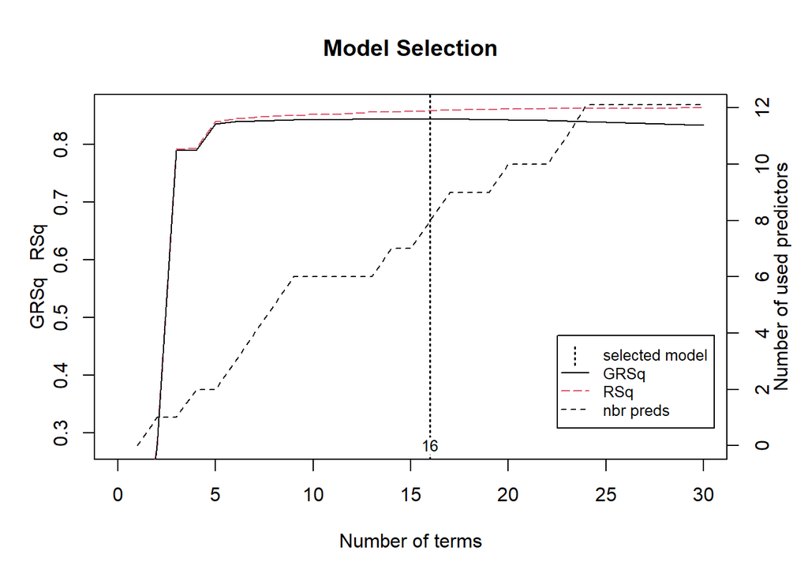

```r
plot(mars1, which=1)
```

Also in this case, the MARS model chose the best model which has a good RSS and GCV. Indeed, the number of unique terms equal to 16 guarantees a good value of GCV before the decrease.

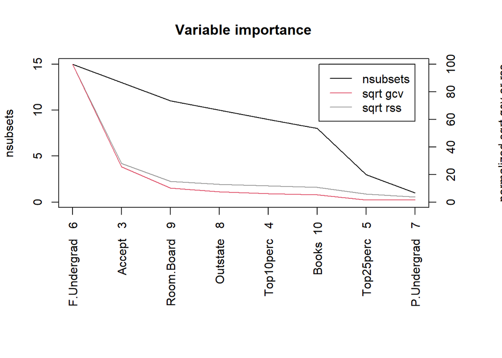

```r
plot(evimp(mars1))
```

See the comment of the previous plot. The conclusion is still the same. Additionally, we can observe that in this case we have more important covariates. *Book*, *Top25perc* and *P.Undergrad*, in this case, contribute a bit to reduce rss and gcv.

```r
#train
pred_mars_1_train <- predict(mars1, train_data[,-18], type = "response")
#val
pred_mars_1 <- predict(mars1, val_data[,-18], type = "response")

pred_mars_1_train <- ifelse(pred_mars_1_train >0.5, 1, 0 )
pred_mars_1 <- ifelse(pred_mars_1 >0.5, 1, 0 )

cat("Accuracy on training data \n")
```

```
## Accuracy on training data
```

```r
(acc_mars_1_train <- accuracy(train_data$Y, pred_mars_1_train)) #0.969
```

```
## [1] 0.9693548
```

```r
cat("Accuracy on validation data \n")
```

```
## Accuracy on validation data
```

```r
(acc_mars_1<- accuracy(val_data$Y, pred_mars_1)) #0.942
```

```
## [1] 0.9423077
```

Also in this case we obtained a good percentage of correct prediction. We can also observe that MARS is able to reduce a bit overfitting issues.